# Module 3: Data visualization II

## Position adjustments

Useful for bar plots and histograms:

- `stack`: stack overlapping bars on top of each other (default).
- `identity`: does nothing to overlapping bars but requires alpha.
  - Helpful for histograms but not bar plots.
- `fill`: stack overlapping bars and scale so the top is always at 1.
  - Helpful for bar plots but not histograms.
- `dodge`: place overlapping bars side-by-side.

Version for scatterplots when many points overlap:

- `position_nudge()`: move points by a fixed offset.
- `position_jitter()`: add a little random noise to every position.
- `position_jitterdodge()`: dodge points within groups, then add a little random noise.

## Position adjustments: Bar charts

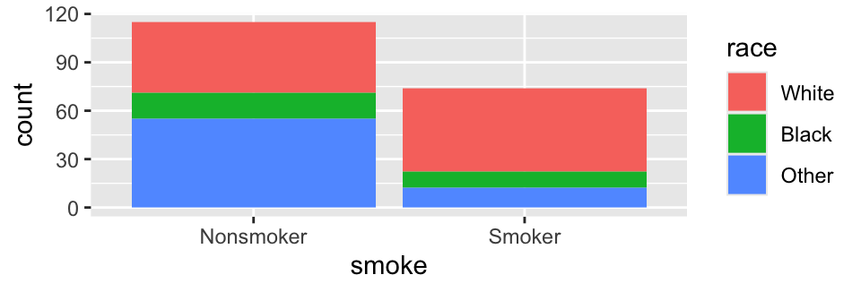

```r
birthwt |>
  ggplot2::ggplot(aes(x = smoke,
                      fill = race) ) +
  ggplot2::geom_bar() # default = stack
```

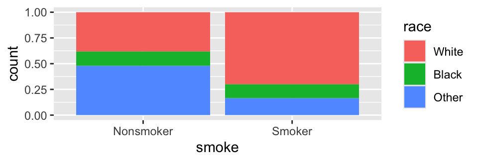

```r
birthwt |>
  ggplot2::ggplot(aes(x = smoke,
                      fill = race) ) +
  ggplot2::geom_bar(position = "fill")
```

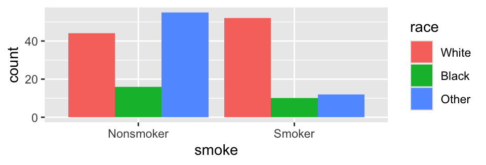

```r
birthwt |>
  ggplot2::ggplot(aes(x = smoke,
                      fill = race) ) +
  ggplot2::geom_bar(position = "dodge")
```

## Position adjustments: Histograms

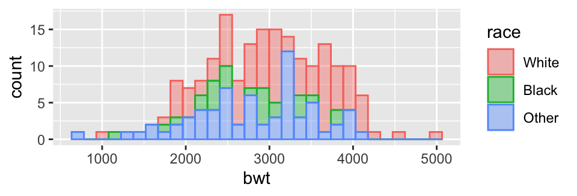

```r
ggplot2::ggplot(birthwt,
                aes(x = bwt,
                    color = race, fill = race)) +
  ggplot2::geom_histogram(position = "stack", # default = stack
                          alpha = 0.4)
```

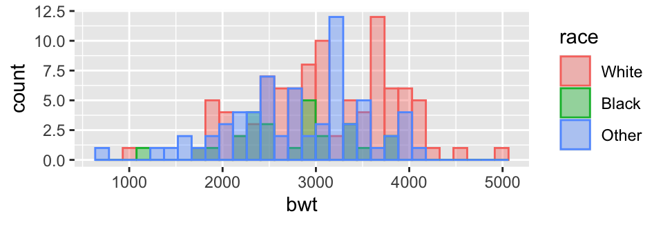

```r
ggplot2::ggplot(birthwt,
                aes(x = bwt,
                    color = race, fill = race)) +
  ggplot2::geom_histogram(position = "identity",
                          alpha = 0.4)
```

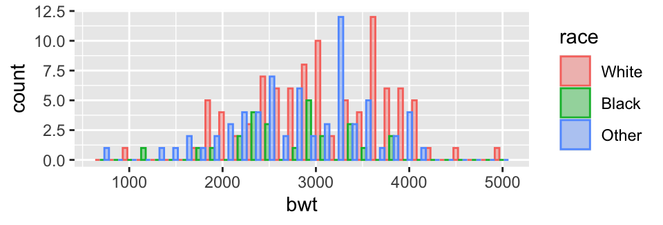

```r
ggplot2::ggplot(birthwt,
                aes(x = bwt,
                    color = race, fill = race)) +
  ggplot2::geom_histogram(position = "dodge",
                          alpha = 0.4)
```

## Exercise: Facets and position adjustments

Create a histogram that compares the distribution of lwt across races. Map race to the color of the histograms. Ensure that each of the histograms is fully visible. Row-wise facet by low birthweight status (`low`).

```
birthwt |>
  dplyr::mutate(race = factor(x = birthwt$race,
                              levels = 1:3,
                              labels = c("White", "Black", "Other"))) |>
  ggplot2::ggplot(aes()) +
  ggplot2::geom_histogram(, alpha = 0.3) +
  ggplot2::facet_grid()
```

## Scales

- Scales control how the aesthetic mappings of variables manifest visually in plots.
  - How a variable is translated into `color`, `size`, `shape`, etc.
- Every aesthetic has a default scale.

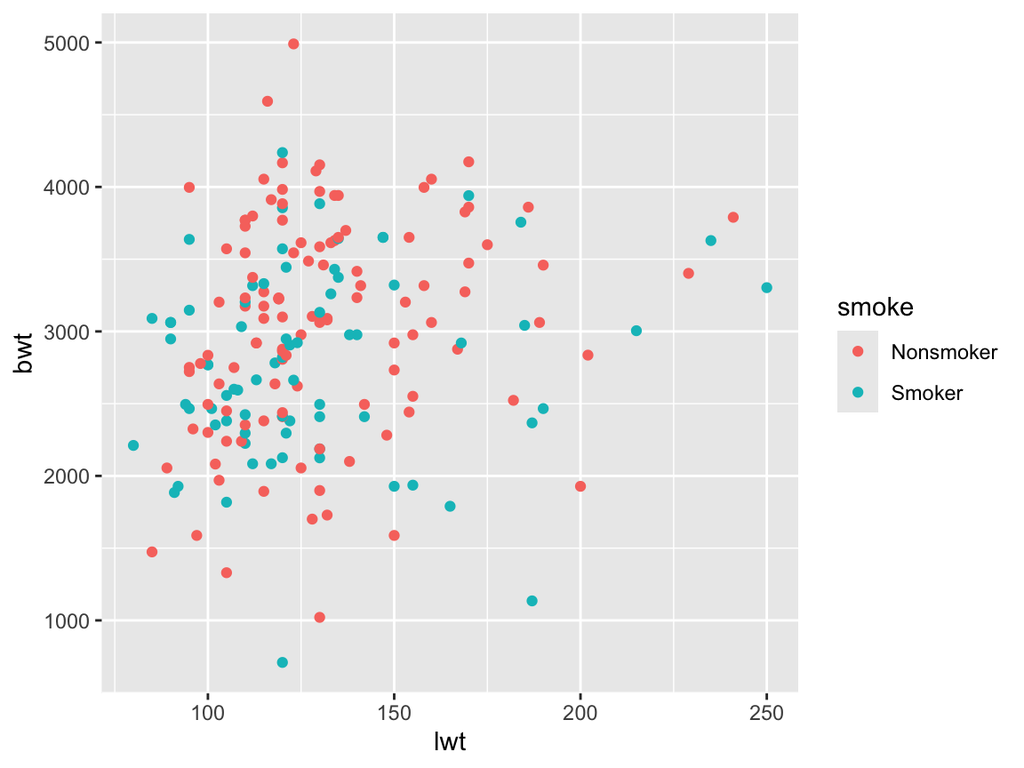

```r
birthwt |>
  ggplot2::ggplot(
    aes(x = lwt, y = bwt)
    ) +
  ggplot2::geom_point(
    aes(color = smoke)
    ) +
  # ggplot adds by default:
  ggplot2::scale_x_continuous() + # x-axis
  ggplot2::scale_y_continuous() + # y-axis
  ggplot2::scale_color_discrete() # color
```

## Overriding default scales

- `ggplot2` has syntax to override default scales.
- General naming scheme: `scales_‘aesthetic’_‘scale’.
  - `breaks` and `labels` are the main arguments used.

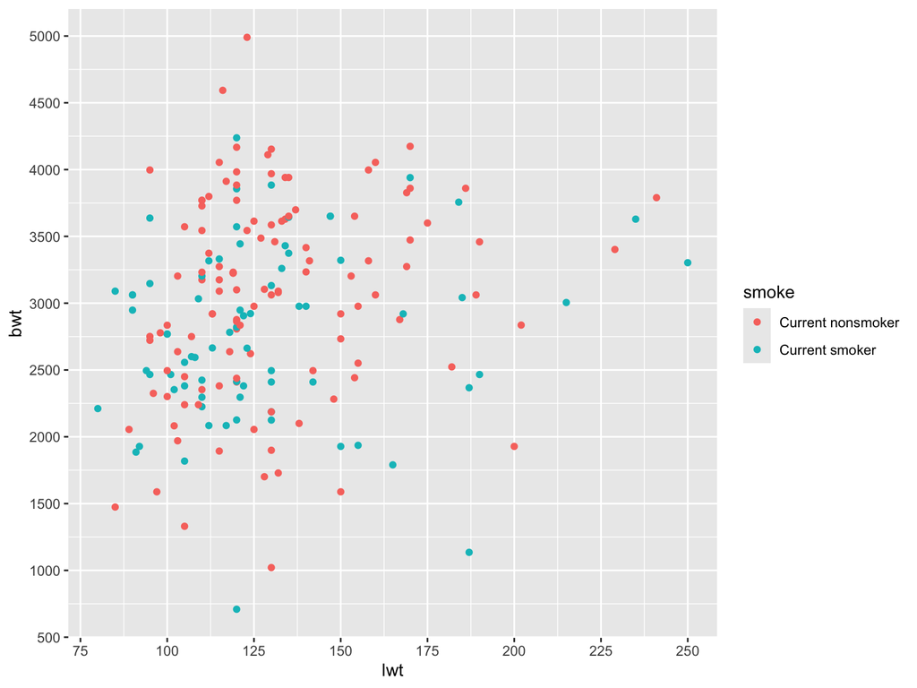

```r
birthwt |>
  ggplot(aes(x = lwt, y = bwt) ) +
  geom_point(aes(color = smoke) ) +
  scale_x_continuous(
    breaks = seq(50, 250, by = 25)
    ) +
  scale_y_continuous(
    breaks = seq(500, 5500, by = 500)
    ) +
  scale_color_discrete(
    labels = c("Smoker" = "Current smoker",
               "Nonsmoker" = "Current nonsmoker"))
```

## Color scales: ColorBrewer

- Discrete color scale with colors picked from ColorBrewer.
  - Some colorblind friendly palettes (e.g., `Dark2`).

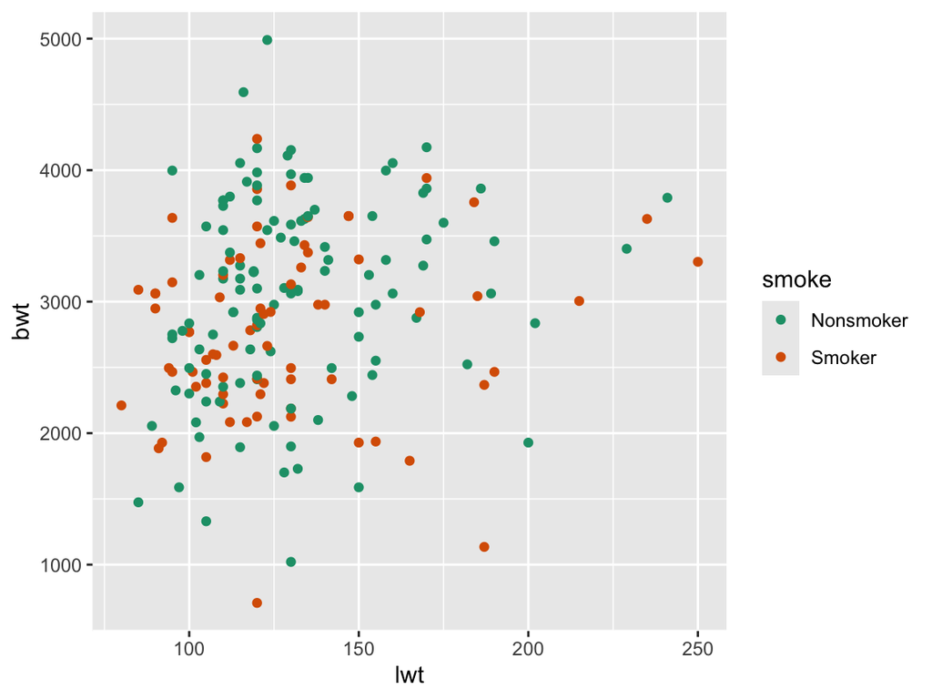

```r
birthwt |>
  ggplot(aes(x = lwt, y = bwt) ) +
  geom_point(aes(color = smoke) ) +
  ggplot2::scale_color_brewer(palette = "Dark2")
```

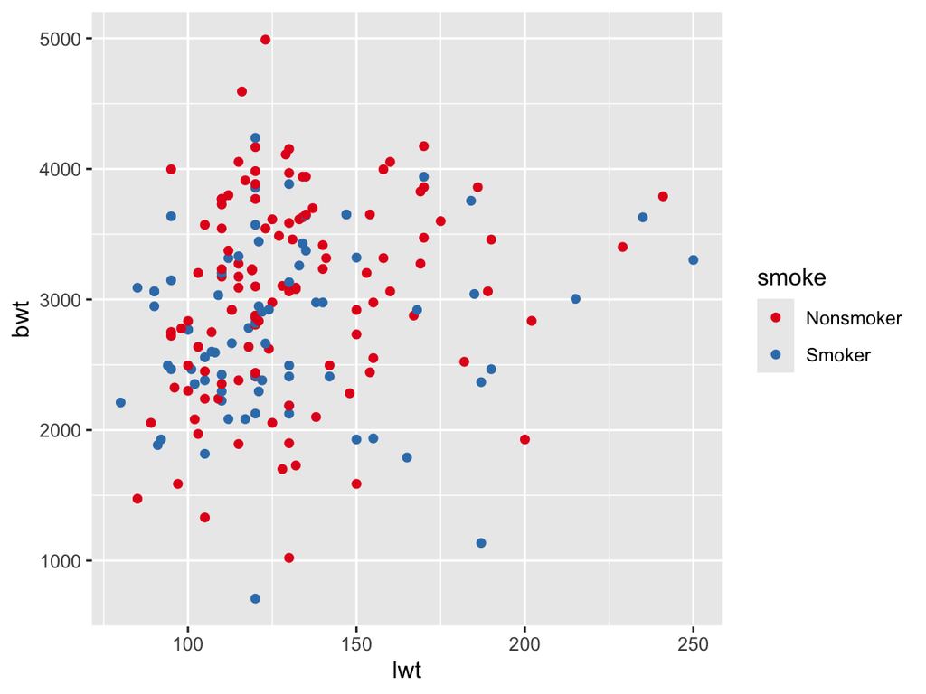

```r
birthwt |>
  ggplot(aes(x = lwt, y = bwt) ) +
  geom_point(aes(color = smoke) ) +
  ggplot2::scale_color_brewer(palette = "Set1")
```

## Color scales: Manual

- It is also possible to supply your own color palette.
  - `ggplot2` quick color [reference](https://sape.inf.usi.ch/quick-reference/ggplot2/colour).
- Or use a palette from a package: wesanderson, waRhol, [ggsci](https://nanx.me/ggsci/), and more.
  - Check the paletteer package for a large, searchable collection.

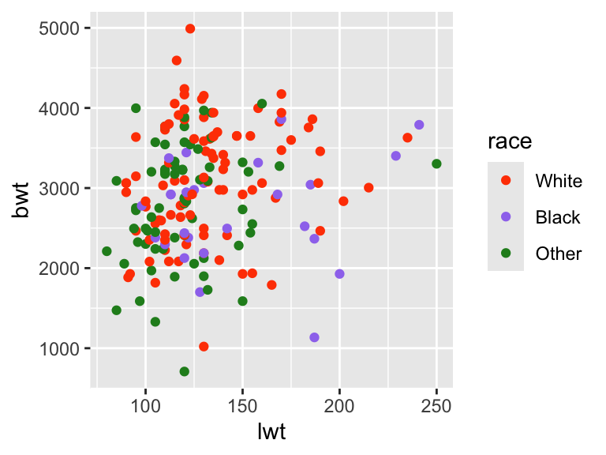

```r
birthwt |>
  ggplot(aes(x = lwt, y = bwt) ) +
  geom_point(aes(color = race) ) +
  ggplot2::scale_color_manual(
    values = c("orangered1",
               "mediumpurple2",
               "forestgreen") )
```

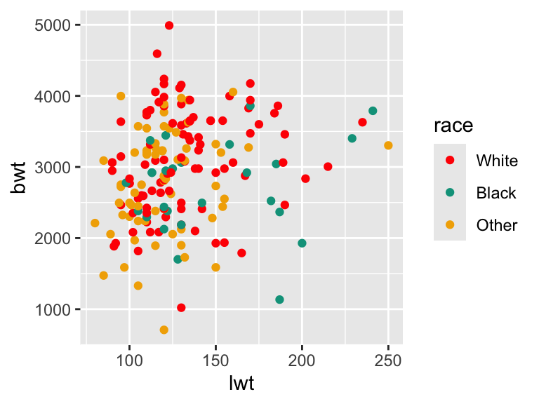

```r
birthwt |>
  ggplot(aes(x = lwt, y = bwt) ) +
  geom_point(aes(color = race) ) +
  ggplot2::scale_color_manual(
    values = wesanderson::wes_palette(
      name = "Darjeeling1",
      n = 3) )
```

## Themes

- [Themes](https://ggplot2-book.org/themes.html) allow you to customize non-data elements of your plot.
- `ggplot2` comes with [eight](https://r4ds.hadley.nz/communication.html#sec-themes) prespecified themes: `theme_*()`.
  - Change multiple aspects of the plot simultaneously.
- `theme()` lets you to change specific elements of the plot to your specification.
  - Text size, color, legend position, etc.

## `theme_*()`

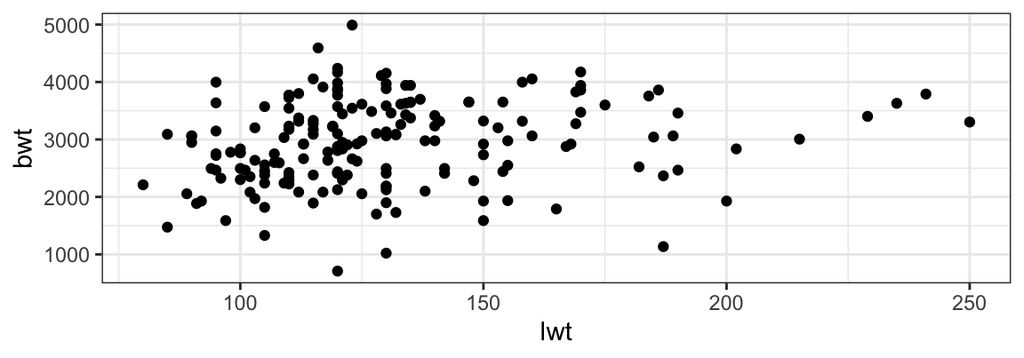

```r
birthwt |>
  ggplot(aes(x = lwt, y = bwt) ) +
  geom_point() +
  ggplot2::theme_bw()
```

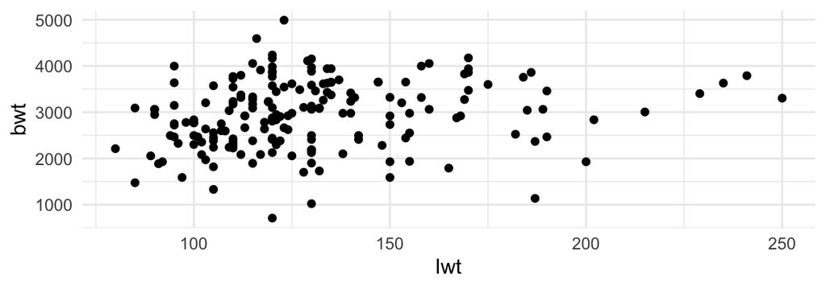

```r
birthwt |>
  ggplot(aes(x = lwt, y = bwt) ) +
  geom_point() +
  ggplot2::theme_minimal()
```

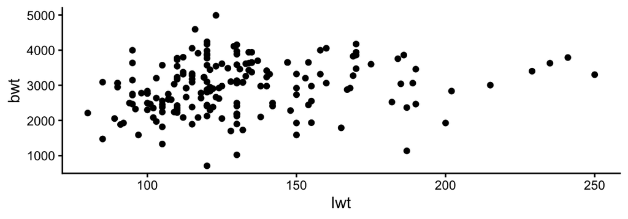

```r
birthwt |>
  ggplot(aes(x = lwt, y = bwt) ) +
  geom_point() +
  ggplot2::theme_classic()
```

## `theme()`

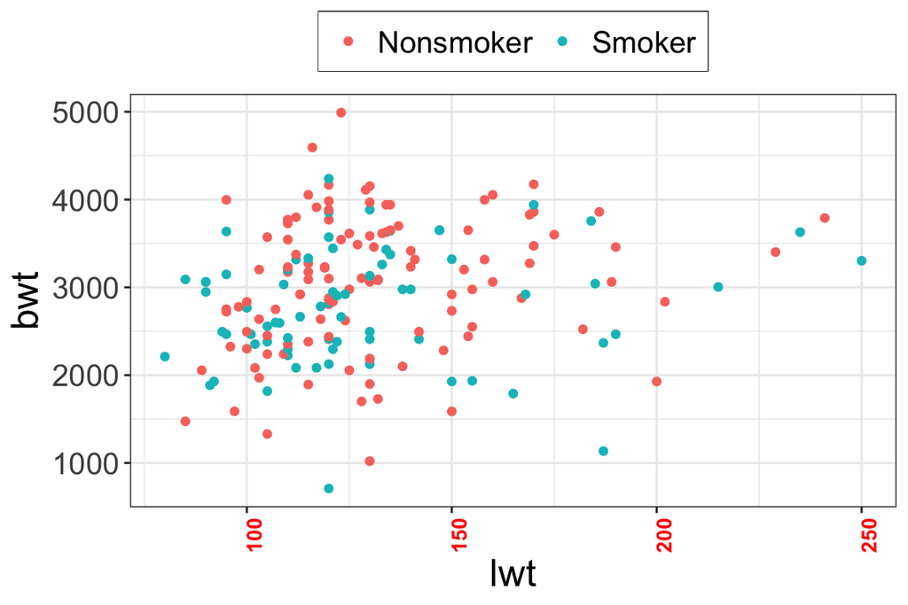

```r
birthwt |>
  ggplot(aes(x = lwt, y = bwt) ) +
  geom_point(aes(color = smoke) ) +
  ggplot2::theme_bw() +
  ggplot2::theme(
    legend.position = "top",
    legend.title = element_blank(),
    legend.box.background = element_rect(color = "black"),
    text = element_text(size = 18),
    axis.text.x = element_text(size = 10, color = "red", angle = 90, face = "bold")
  )
```

## Exercise: Themes

Create a boxplot of birthweight by smoking status.

1. Change the boxplot colors to dark blue and orange.
2. Increase the y-axis by 500 grams per tick mark.
3. Change the x-axis title to “Smoking status”
4. Make the background plain white with no grid lines using a `theme_*`.
5. Remove the legend and bold the title.

```
birthwt |>
  dplyr::mutate(smoke = factor(birthwt$smoke, levels = 0:1,
                               labels = c("Nonsmoker", "Smoker"))) |>
  ggplot2::ggplot(aes(x = smoke, y = bwt, fill = smoke)) +
  ggplot2::geom_boxplot() +
  ggplot2::( = c("darkblue", "orange")) +
  ggplot2::scale_y_continuous(name = "Birthweight (grams)",
                               = seq(0, 5000,  = 500) ) +
  ggplot2::(name = "Smoking status") +
  ggplot2::labs(title = "Birth Weight by Smoking Status") +
  ggplot2::() +
  ggplot2::theme(legend.position = "",
                 plot.title = (face = "bold", hjust = 0.5) )
```

## Patchwork: Combining plots

- We often have many related plots that we want to combine into one figure.
- `+` combines plots, automatically choosing the number of rows/columns.
- `/` stacks plots vertically; `|` places plots side by side (and does not autowrap).

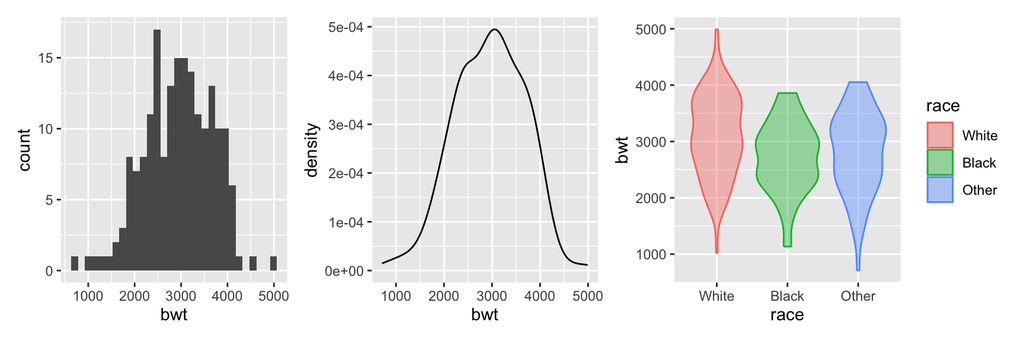

```r
# need to load patchwork package for "+", "/", and "|" notation to work
histPlot.bwt + densityPlot.bwt + violinPlot.bwt.race
```

## Patchwork: Combining plots

- Add titles, captions, and control relative panel sizes with `plot_annotation()` and `plot_layout()`.

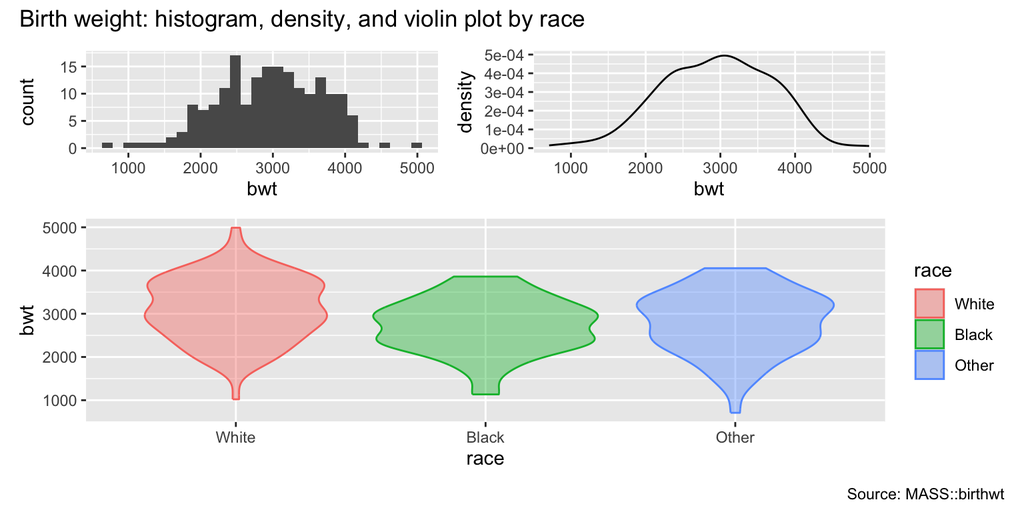

```r
(histPlot.bwt | densityPlot.bwt) / violinPlot.bwt.race +
  patchwork::plot_annotation(
    title = "Birth weight: histogram, density, and violin plot by race",
    caption = "Source: MASS::birthwt"
    ) +
  patchwork::plot_layout(
    heights = c(1, 2) # ratio of heights
    )
```

## Saving plots

- Once you’ve made a plot, you may want to save it to share with others or to include in a paper or presentation.

```r
ggplot2::ggsave(filename = here::here("output/YYYYMMDD_module03-birthwt-violinPlot.pdf"),
                plot = violinPlot.bwt.race,
                height = 6,
                width = 12)
```

- File name conventions should be used (informative and dated).
- If `plot` is not specified, the most recent plot displayed is saved.
- If `height` and `width` aren’t specified, the dimensions of the current plot are used.
  - Aspect ratios (width:height) of 2:1 or 4:3 are preferred.
- Saving to .pdf gives the highest resolution.
  - Although other file types are support (.png, .jpeg).

# Appendix

## Why visualize?

- Summarizing data is fundamental to statistics.
- Numeric summaries (mean, variance, correlation, etc.) are common and informative.
- Pairing numeric summaries with data visualizations provides deeper insights, some that may be missed by numerical analysis alone.

## Why visualize: 13 data sets

```r
head(datasauRus::datasaurus_dozen, n = 3)
```

```
# A tibble: 3 × 3
  dataset     x     y
  <chr>   <dbl> <dbl>
1 dino     55.4  97.2
2 dino     51.5  96.0
3 dino     46.2  94.5
```

```r
datasauRus::datasaurus_dozen |>
  dplyr::summarise(.by = dataset,
                   mean.x = mean(x),
                   mean.y = mean(y),
                   sd.x = sd(x),
                   sd.y = sd(y),
                   corr = round(cor(x,y), 2)
                   )
```

```
# A tibble: 13 × 6
   dataset    mean.x mean.y  sd.x  sd.y  corr
   <chr>       <dbl>  <dbl> <dbl> <dbl> <dbl>
 1 dino         54.3   47.8  16.8  26.9 -0.06
 2 away         54.3   47.8  16.8  26.9 -0.06
 3 h_lines      54.3   47.8  16.8  26.9 -0.06
 4 v_lines      54.3   47.8  16.8  26.9 -0.07
 5 x_shape      54.3   47.8  16.8  26.9 -0.07
 6 star         54.3   47.8  16.8  26.9 -0.06
 7 high_lines   54.3   47.8  16.8  26.9 -0.07
 8 dots         54.3   47.8  16.8  26.9 -0.06
 9 circle       54.3   47.8  16.8  26.9 -0.07
10 bullseye     54.3   47.8  16.8  26.9 -0.07
11 slant_up     54.3   47.8  16.8  26.9 -0.07
12 slant_down   54.3   47.8  16.8  26.9 -0.07
13 wide_lines   54.3   47.8  16.8  26.9 -0.07
```

## Why visualize: 13 data sets

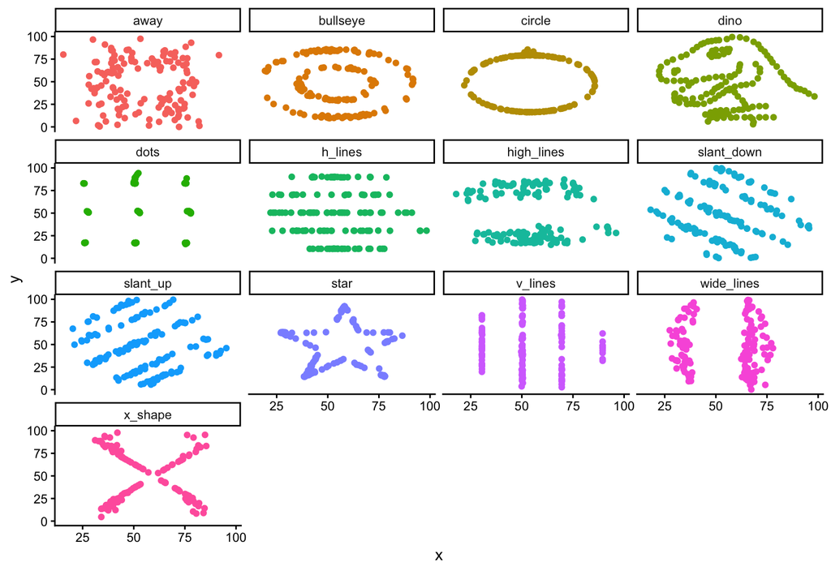

From: [Same Stats, Different Graphs](https://dl.acm.org/doi/10.1145/3025453.3025912)

## Visualize in multiple ways

```r
datasauRus::box_plots
```

```
# A tibble: 2,484 × 5
    left lines normal right split
   <dbl> <dbl>  <dbl> <dbl> <dbl>
 1 -9.77 -9.77  -9.76 -9.76 -9.77
 2 -9.76 -9.74  -9.72 -9.05 -9.77
 3 -9.75 -9.77  -9.68 -8.51 -9.77
 4 -9.77 -9.77  -9.64 -8.24 -9.77
 5 -9.76 -9.77  -9.6  -8.82 -9.77
 6 -9.77 -9.76  -9.56 -8.07 -9.76
 7 -9.76 -9.76  -9.52 -7.06 -9.75
 8 -9.76 -9.76  -9.48 -8.67 -9.76
 9 -9.77 -9.77  -9.44 -8.44 -9.77
10 -9.77 -9.77  -9.4  -6.79 -9.77
# ℹ 2,474 more rows
```

```r
datasauRus::box_plots_long |>
  dplyr::summarise(
    .by = Plot,
    Q1 = quantile(Values,
                  probs = 0.25),
    median = round(median(Values),
                   digits = 2),
    Q3 = quantile(Values,
                  probs = 0.75)
    )
```

```
# A tibble: 5 × 4
  Plot      Q1 median    Q3
  <chr>  <dbl>  <dbl> <dbl>
1 left   -2.69  -0.01  2.67
2 lines  -2.69  -0.01  2.67
3 normal -2.68   0     2.68
4 right  -2.68   0     2.68
5 split  -2.69   0     2.68
```

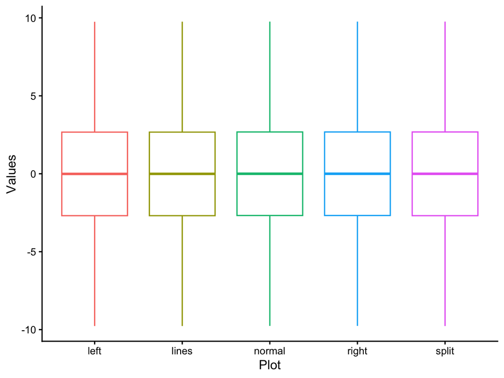

## Visualize in multiple ways

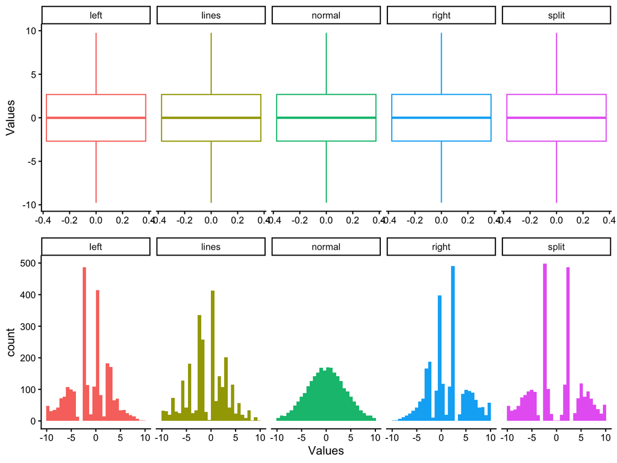

## Visualize with mappings

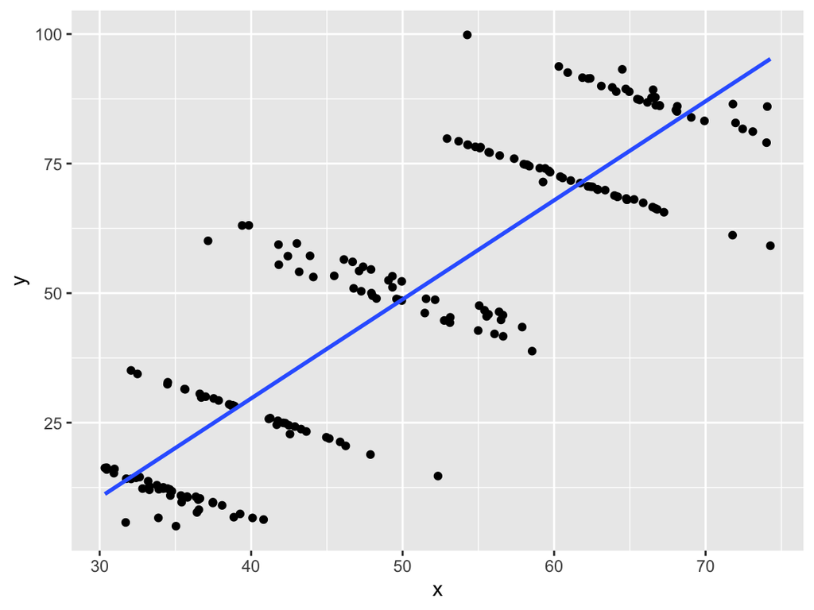

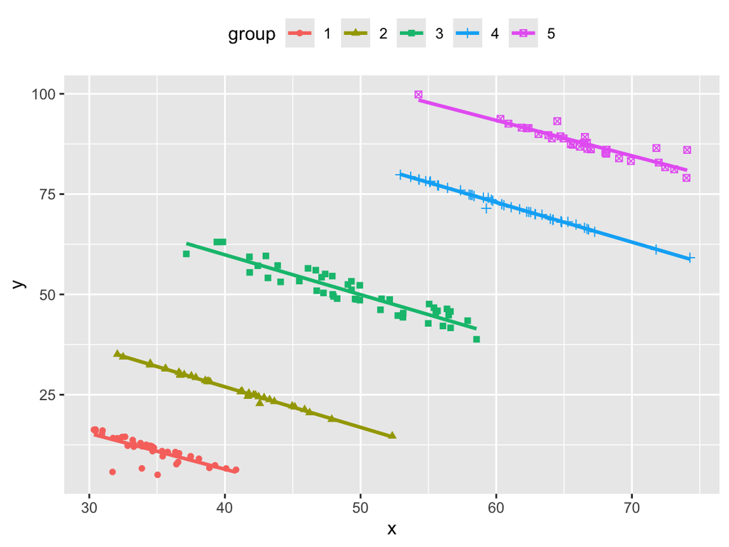

- The overall trend line is positive, but when a third variable is added to the plot via `aes()` it is clear that within each group the trend line is negative.